# Nonparametric two-sample testing

Kemeng Zhang

2018-05-11

## Introduction

The nonparametric two-sample hypothesis testing problem involves: given X_1, X_2, …, X_n i.i.d. F and Y_1, Y_2, …, Y_m i.i.d. G, test the null hypothesis of F = G against the alternative hypothesis of F is not equal to G. The test statistic is based on embedding F and G into a reproducing kernel Hilbert space and then compute a distance between the resulting embeddings. For this primitive, the Hilbert space is associated with the Gaussian kernel.

## Testing/Simulation

### Stochastic Blockmodel Example

We illustrate the hypothesis tests through simulated examples. Let F_epsilon for a given epsilon > 0 be mixture of point masses corresponding to a two-block stochastic block model with block membership probabilities (0.4,0.6) and block probabilities 0.23+epsilon if in the same block, 0.76 otherwise.

Suppose we are given two graphs G ~ F_0 (known) and G_epsilon ~ F_epsilon (unknown). We then test, for a given epsilon > 0, the hypothesis whether F_0 and F_epsilon are the same distribution. We will use bootstrapping to conduct hypothesis testing. First, we need to construct a sampling distribution of our test statistic. Under null, we sample two graphs on 100 vertices from RDPG(F_0), then compute our test statistic using nonpar() 200 times. Then we can construct a rejection region and test whether the test statistic of G and G_epsilon lies inside that region (therefore we reject the null; otherwise, we fail to reject the null).

```r
# Generate Adjacency Matrix
sbm <- function(epsilon) {
  n <- 100
  blocks <- c(rep(0, n*0.4), rep(1, n*0.6))
  A <- matrix(rep(0, n*n), nrow = n)
  for (i in 2:n) {
    for (j in 1:(i-1)) {
      if (blocks[i] == blocks[j]) {
        A[i, j] <- rbinom(1, 1, 0.23 + epsilon)
      } else {
        A[i, j] <- rbinom(1, 1, 0.76)
      }
      A[j, i] <- A[i, j]
    }
  }
  g <- igraph::graph_from_adjacency_matrix(A)
  g
}
```

Now, we are given two graphs to perform hypothesis testing: G ~ F_0, G_epsilon ~ F_epsilon;

where we set epsilon to be 0.01.

```r
g = sbm(0)
g_epsilon = sbm(0.01)
```

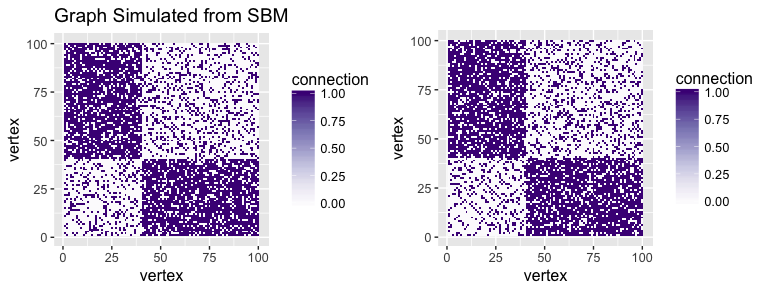

```r
A_sbm <- igraph::as_adj(g)
A = matrix(A_sbm, nrow = 100)
A_epsilon_sbm <- igraph::as_adj(g_epsilon)
A_epsilon = matrix(A_epsilon_sbm, nrow = 100)
g1 = gs.plot.plot_matrix(A, legend.name = "connection", xlabel = "vertex",
                    ylabel = "vertex", title = "Graph Simulated from SBM")
g2 = gs.plot.plot_matrix(A_epsilon, legend.name = "connection",
                         xlabel ="vertex", ylabel = "vertex")
grid.arrange(g1, g2, nrow = 1)
```

Now, we can embed two graphs to R^2 and compare their latent positions:

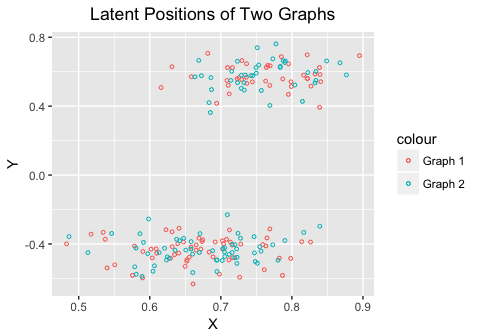

```r
embed.graph <- function(g, dim) {
  # Call ase to get latent position
  lpv = graphstats::ase(g, dim)
  for (i in 1:dim) {
    if (sign(lpv[1, i]) != 1) {
      lpv[, i] = -lpv[, i]
    }
  }
  return(lpv)
}
Xhat = embed.graph(g, 2)
Xhat_epsilon = embed.graph(g_epsilon, 2)
Xhat_df = as.data.frame(Xhat)
Xhat_epsilon_df = as.data.frame(Xhat_epsilon)
gg <- ggplot(Xhat_df, aes(x=V1, y=V2, color = "Graph 1")) +
  geom_point(size=1, shape=1)
gg + geom_point(data = Xhat_epsilon_df, aes(x=V1, y=V2,color = "Graph 2"),
                size=1, shape=1) +
  labs(title="Latent Positions of Two Graphs", x="X", y="Y") +
  theme(plot.title = element_text(hjust = 0.5))
```

Now, the significance level is set to alpha = 0.05 and the rejection regions are specified via B = 200 bootstrap permutation using the estimated latent positions.

```r
np = nonpar(g, g_epsilon)
```

```
## [1] "Fail to reject the null hypothesis that two graphs are identically distributed."
```

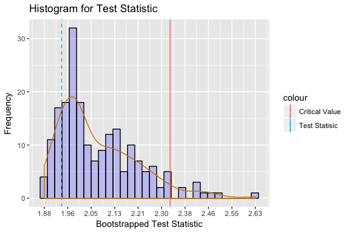

```r
np$plot
```

We reject the null hypothesis if test statistic yielded by G and G_epsilon are in the top 5% of test_distribution (to the right of the red vertical line). Here we failed to reject our null because our test statistic is inside the acceptance region.